# Ex1

```python
import networkx as nx
import matplotlib.pyplot as plt
import numpy as np
import pandas as pd
from scipy.linalg import expm
```

## Basic graph functions

```python
def plot_graph(G):
    plt.figure(figsize=(10,10))
    pos=nx.spring_layout(G)
    nx.draw(G, with_labels = True, pos = pos)
    plt.show(True)

def read_graph(filepath):
    G= nx.read_edgelist(filepath, nodetype=int, comments='%') # Read the network
    Gcc=sorted(nx.connected_component_subgraphs(G), key = len, reverse=True)
    G=Gcc[0]
    G = nx.convert_node_labels_to_integers(G, first_label=0)
    N = len(G)
    M = G.number_of_edges()
    print('Number of nodes:', N)
    print('Number of edges:', M)
    return G

def read_gml_graph(filepath):
    M= nx.read_gml(filepath) # Read the network
    G = nx.Graph()
    for u,v,data in M.edges(data=True):
        w = data['weight'] if 'weight' in data else 1.0
        if G.has_edge(u,v):
            G[u][v]['weight'] += w
        else:
            G.add_edge(u, v, weight=w)
    Gcc=sorted(nx.connected_component_subgraphs(G), key = len, reverse=True)
    G=Gcc[0]
    G = nx.convert_node_labels_to_integers(G, first_label=0)
    N = len(G)
    M = G.number_of_edges()
    print('Number of nodes:', N)
    print('Number of edges:', M)
    return G

def read_digraph(filepath):
    G= nx.read_edgelist(filepath, create_using=nx.DiGraph, nodetype=int, comments='%') # Read the network
    Gcc=sorted(nx.connected_component_subgraphs(G), key = len, reverse=True)
    G=Gcc[0]
    G = nx.convert_node_labels_to_integers(G, first_label=0)
    N = len(G)
    M = G.number_of_edges()
    print('Number of nodes:', N)
    print('Number of edges:', M)
    return G

def read_graph_weighted(filepath):
    G= nx.read_edgelist(filepath, nodetype=int, data=(('weight',float),), comments='%') # Read the network
    Gcc=sorted(nx.connected_component_subgraphs(G), key = len, reverse=True)
    G=Gcc[0]
    G = nx.convert_node_labels_to_integers(G, first_label=0)
    N = len(G)
    M = G.number_of_edges()
    print('Number of nodes:', N)
    print('Number of edges:', M)
    return G
```

## Functions for the centrality measures

```python
def degree_centrality(G):
    vk = dict(G.degree())
    vk = list(vk.values())
    plt.figure(figsize=(6,4))
    plt.hist(vk, density=True)
    plt.title("Distribution of the Degree Centrality", fontsize=20)
    plt.ylabel("P(k)", fontsize=20)
    plt.xlabel("Degree Centrality (k)", fontsize=20)
    plt.show(True)
    return vk

def closeness_centrality(G):
    CLC = dict(nx.closeness_centrality(G))
    CLC = list(CLC.values())
    plt.figure(figsize=(6,4))
    plt.hist(CLC, density=True)
    plt.title("Distribution of the Closeness Centrality", fontsize=20)
    plt.ylabel("P(CLC)", fontsize=20)
    plt.xlabel("Closeness Centrality (CLC)", fontsize=20)
    plt.show(True)
    return CLC

def betweenness_centrality(G):
    B = dict(nx.betweenness_centrality(G))
    B = list(B.values())
    plt.figure(figsize=(6,4))
    plt.hist(B, density=True)
    plt.title("Distribution of the betweenness centrality", fontsize=20)
    plt.ylabel("P(B)", fontsize=20)
    plt.xlabel("Betweenness centrality (B)", fontsize=20)
    plt.show(True)
    return B

def page_rank(G):
    PR = dict(nx.pagerank(G, alpha=0.85))
    PR = list(PR.values())
    plt.figure(figsize=(6,4))
    plt.hist(PR, density=True)
    plt.title("Distribution of the PageRank", fontsize = 20)
    plt.ylabel("P(PR)", fontsize = 20)
    plt.xlabel("PageRank (PR)",fontsize = 20)
    plt.show(True)
    return PR

def k_core(G):
    KC= dict(nx.core_number(G))
    KC = list(KC.values())
    plt.figure(figsize=(6,4))
    plt.hist(KC, density=True)
    plt.title("Distribution of the Core Number", fontsize = 20)
    plt.ylabel("P(KC)", fontsize = 20)
    plt.xlabel("Core Number (KC)", fontsize = 20)
    plt.savefig('kcore.eps')
    plt.show(True)
    return KC

def eigenvector_centrality(G):
    EC = dict(nx.eigenvector_centrality(G, max_iter = 1000))
    EC = list(EC.values())
    plt.figure(figsize=(6,4))
    plt.hist(EC, density=True)
    plt.title("Distribution of the Eigenvector Centrality",fontsize=20)
    plt.ylabel("P(EC)", fontsize=20)
    plt.xlabel("Eigenvector Centrality (EC)", fontsize=20)
    plt.show(True)
    return EC

def random_walk_accessibility(G):
    RW = dict(nx.current_flow_betweenness_centrality(G, dtype=np.float32))
    RW = list(RW.values())
    plt.figure(figsize=(6,4))
    plt.hist(RW, density=True)
    plt.title("Distribution of the Random Walk Accessibility",fontsize=20)
    plt.ylabel("P(RW)", fontsize=20)
    plt.xlabel("Random Walk Accessibility (RW)", fontsize=20)
    plt.show(True)
    return RW

def communicability_centrality(G):
    COM = dict(nx.communicability_exp(G))
    COM = list(COM.values())
    returnCOM = []
    for i in range(len(COM[0])):
        returnCOM.append(COM[i][i])
    plt.figure(figsize=(6,4))
    plt.hist(returnCOM, density=True)
    plt.title("Distribution of the Communicability Centrality",fontsize=20)
    plt.ylabel("P(COM)", fontsize=20)
    plt.xlabel("Communicability Centrality (COM)", fontsize=20)
    plt.show(True)
    return returnCOM
```

## Function for the correlation matrix

```python
def correlation_matrix(vk, CLC, B, EC, PR, KC, RW, COM):
    df = pd.DataFrame({'K':vk,'CLC':CLC,'B':B,'EC':EC,'PR':PR,'KC':KC, 'RW': RW, 'COM': COM})
    corr = df.corr()
    plt.figure(figsize=(8,8))
    plt.imshow(corr, cmap='Blues', interpolation='none', aspect='auto')
    plt.colorbar()
    plt.xticks(range(len(corr)), corr.columns, rotation='vertical', fontsize=20)
    plt.yticks(range(len(corr)), corr.columns, fontsize=20)
    plt.suptitle('Correlation between centrality measures', fontsize=20)
    plt.grid(False)
    plt.show()
```

# Exercise 1 - a) E-Road Network

## Read the graph

```python
G = read_graph("data/euroroad.txt")
```

```
Number of nodes: 1039
Number of edges: 1305
```

## Plot the graph

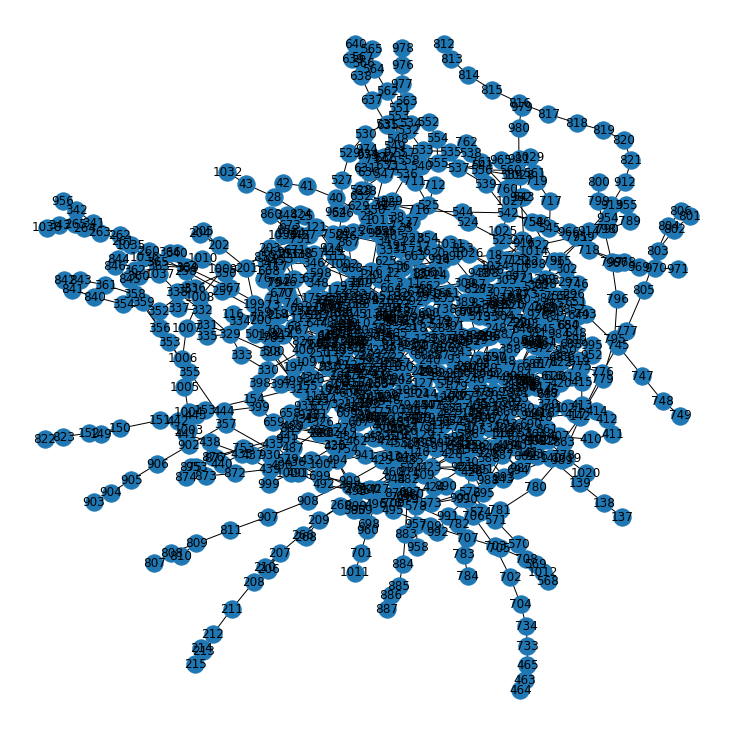

```python
plot_graph(G)
```

## Degree Centrality of the E-Road Network

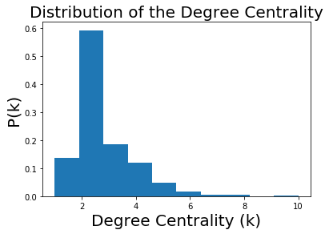

```python
vk = degree_centrality(G)
```

## K-core Centrality of the E-Road Network

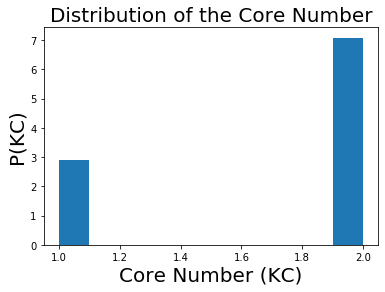

```python
KC = k_core(G)
```

## Closeness Centrality of the E-Road Network

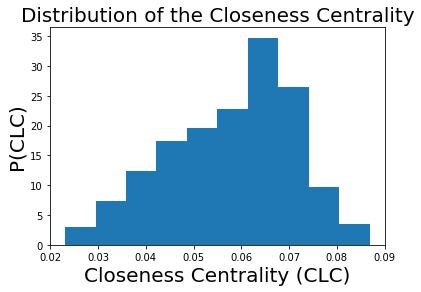

```python
CLC = closeness_centrality(G)
```

## Betweenness Centality of the E-Road Network

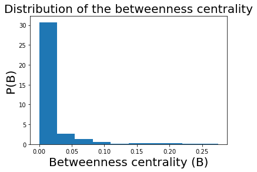

```python
B = betweenness_centrality(G)
```

## Eigenvector Centrality of the E-Road Network

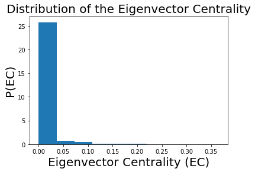

```python
EC = eigenvector_centrality(G)
```

## Pagerank Of The E-Road Network

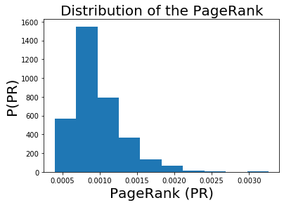

```python
PR = page_rank(G)
```

## Random Walk Accessibility of the E-Road Network

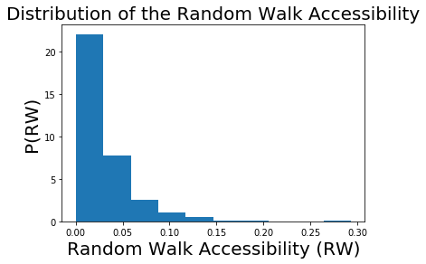

```python
RW = random_walk_accessibility(G)
```

## Communicability Centrality of the E-Road Network

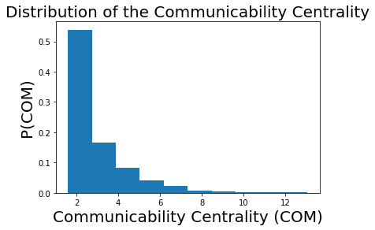

```python
COM = communicability_centrality(G)
```

## Correlation matrix of the centrality measures

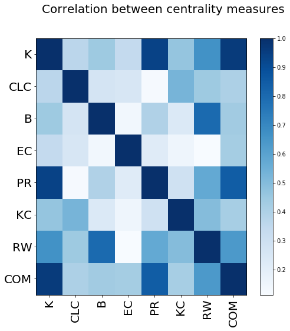

```python
correlation_matrix(vk, CLC, B, EC, PR, KC, RW, COM)
```

## As we can see, Degree Centrality has the highest correlation with Communicability Centrality and Page-Rank, which probably means that the nodes with the higher degree are also the nodes with higher importance in the network and are connected with other important nodes. These nodes are also the ones who can communicate better with the network as a whole.

# Exercise 1 - b) Hamsterster friendships

## Read the graph

```python
G = read_graph("data/out.petster-friendships-hamster-uniq")
```

```
Number of nodes: 1788
Number of edges: 12476
```

## Plot the graph

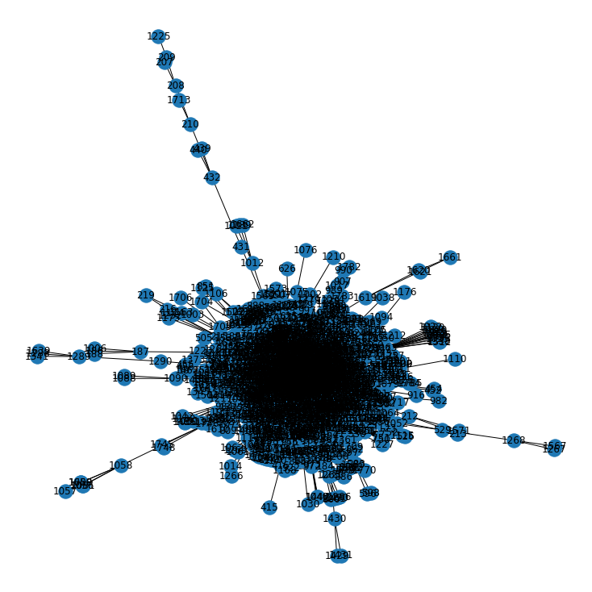

```python
plot_graph(G)
```

## Degree Centrality of the Hamsterster friendships Network

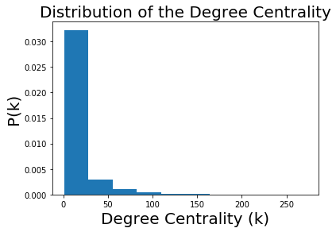

```python
vk = degree_centrality(G)
```

## K-core Centrality of the Hamsterster friendships Network

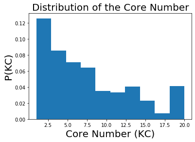

```python
KC = k_core(G)
```

## Closeness Centrality of the Hamsterster friendships Network

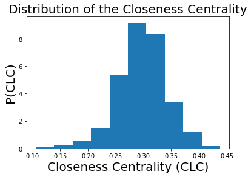

```python
CLC = closeness_centrality(G)
```

## Betweenness Centality of the Hamsterster friendships Network

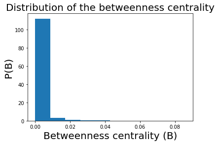

```python
B = betweenness_centrality(G)
```

## Eigenvector Centrality of the Hamsterster friendships Network

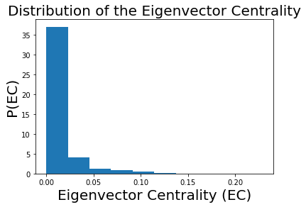

```python
EC = eigenvector_centrality(G)
```

## Pagerank Of The Hamsterster friendships Network

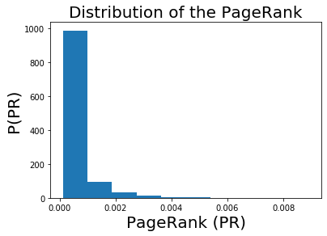

```python
PR = page_rank(G)
```

## Random Walk Accessibility of the Hamsterster friendships Network

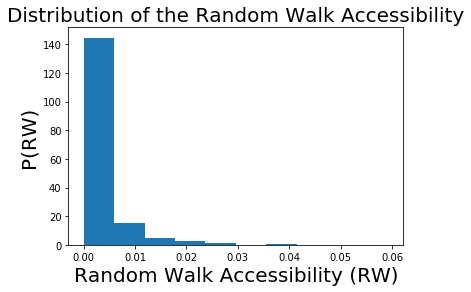

```python
RW = random_walk_accessibility(G)
```

## Communicability Centrality of the Hamsterster friendships Network

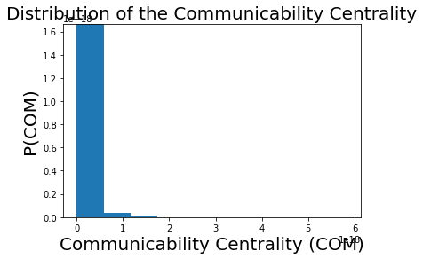

```python
COM = communicability_centrality(G)
```

## Correlation matrix of the centrality measures

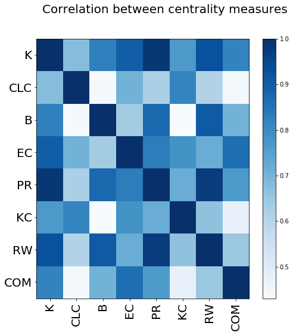

```python
correlation_matrix(vk, CLC, B, EC, PR, KC, RW, COM)
```

## The Degree Centrality has a high correlation with Page-Rank in this network meaning the most connected nodes are also the most important in this network. The Random Walk Accessibility also has a high correlation with Page-Rank because the most important nodes are being visited more frequently when random walks are taken, which probably means they are not part of the shortest paths, otherwise the correlation between RW and B would be higher.

# Exercise 1 - c) C. Elegans Neural Network

## Read the graph

```python
G = read_gml_graph("data/celegansneural.gml")
```

```
Number of nodes: 297
Number of edges: 2148
```

## Plot the graph

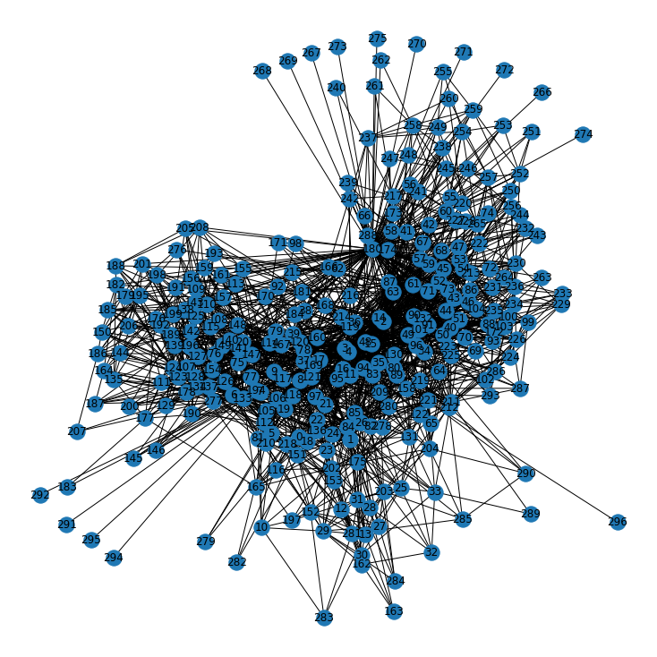

```python
plot_graph(G)
```

## Degree Centrality of the C. Elegans Neural Network

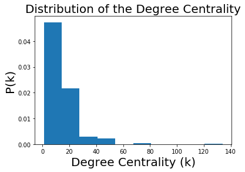

```python
vk = degree_centrality(G)
```

## K-core Centrality of the C. Elegans Neural Network

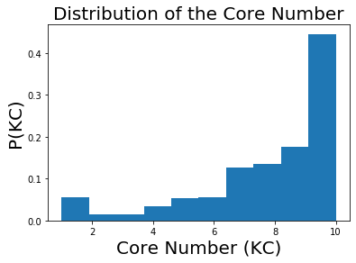

```python
KC = k_core(G)
```

## Closeness Centrality of the C. Elegans Neural Network

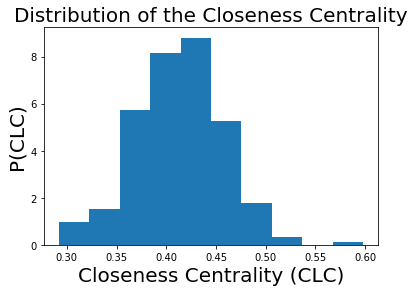

```python
CLC = closeness_centrality(G)
```

## Betweenness Centality of the C. Elegans Neural Network

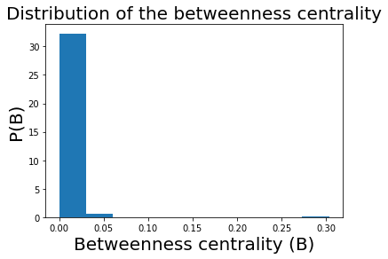

```python
B = betweenness_centrality(G)
```

## Eigenvector Centrality of the C. Elegans Neural Network

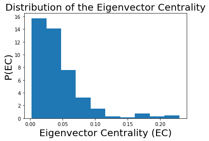

```python
EC = eigenvector_centrality(G)
```

## Pagerank Of The C. Elegans Neural Network

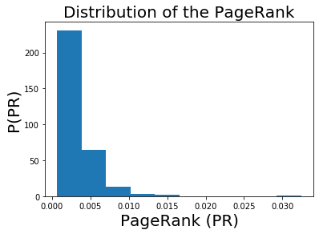

```python
PR = page_rank(G)
```

## Random Walk Accessibility of the C. Elegans Neural Network

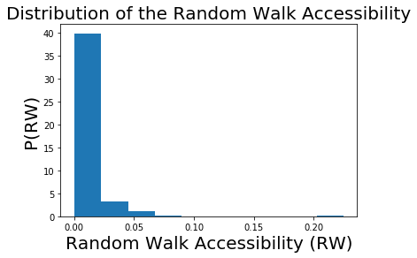

```python
RW = random_walk_accessibility(G)
```

## Communicability Centrality of the C. Elegans Neural Network

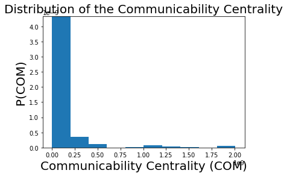

```python
COM = communicability_centrality(G)
```

## Correlation matrix of the centrality measures

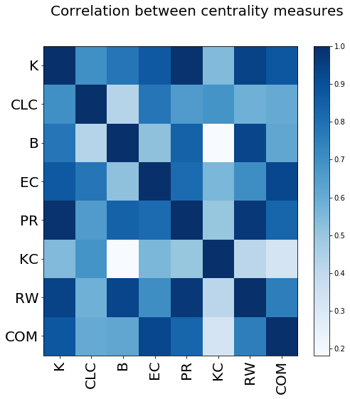

```python
correlation_matrix(vk, CLC, B, EC, PR, KC, RW, COM)
```

## As we can see, Degree Centrality has the highest correlation with Page-Rank, which probably means that the nodes with the higher degree are also the nodes with higher importance in the network and are connected with other important nodes. There's also a high correlation between Degree Centrality and Random Walk Accessibility which means the high degree nodes are also the ones visited the most during random walks (more likely to be visited). The Page-Rank and Random Walk Accessibility are also highly correlated because the most visited nodes are also the most important

# Exercise 1 - d) USA Airport Network

## Read the graph

```python
G = read_graph_weighted("data/usairport.txt")
```

```
Number of nodes: 1572
Number of edges: 17214
```

## Plot the graph

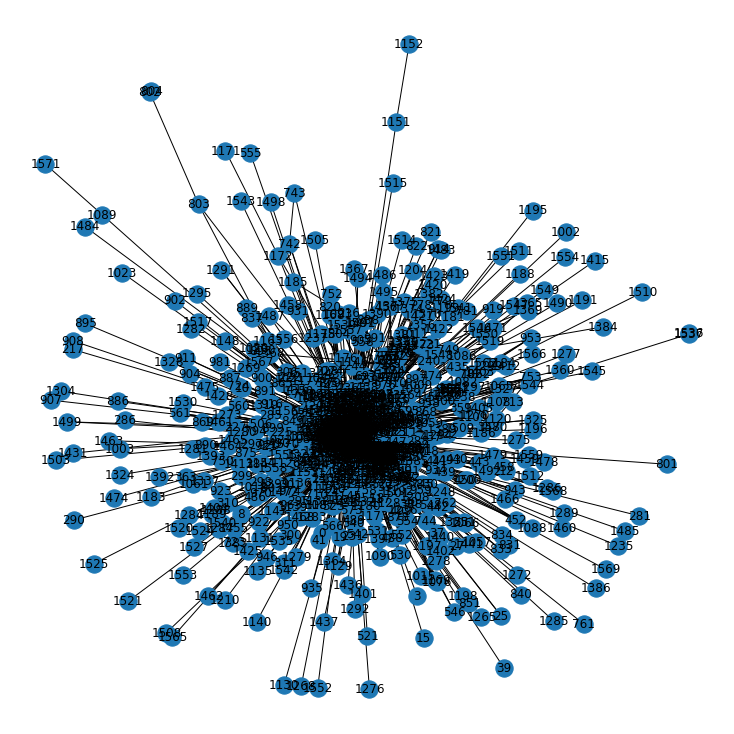

```python
plot_graph(G)
```

## Degree Centrality of the USA Airport Network

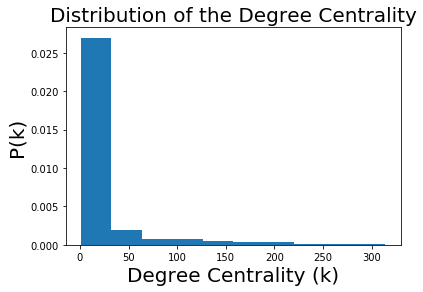

```python
vk = degree_centrality(G)
```